# Mental Health Admissions by Moon Cycle

Wellsin Price

2023-01-16

# Mental Health Admissions and Full Moons

## Data analysis reproducing findings of Blackman, S., and Catalina, D.(1973).

The purpose of this script is to reproduce Blackman and Catalina’s conclusion by way of computational analysis. The motivation is to demonstrate both programming and statistical thinking skills.

### Load Libraries and dataset

```r
library(tidyverse) # Data Science toolbox
library(Stat2Data) # Dataset
library(infer) # For statistical analysis
```

```r
data("MentalHealth") # Loaded from Stat2Data
MentalHealth # Observe the imported dataset
```

```
##    Month   Moon Admission
## 1    Aug Before       6.4
## 2    Sep Before       7.1
## 3    Oct Before       6.5
## 4    Nov Before       8.6
## 5    Dec Before       8.1
## 6    Jan Before      10.4
## 7    Feb Before      11.5
## 8    Mar Before      13.8
## 9    Apr Before      15.4
## 10   May Before      15.7
## 11   Jun Before      11.7
## 12   Jul Before      15.8
## 13   Aug During       5.0
## 14   Sep During      13.0
```

[output cut: 22 more lines]

### Data Exploration and Wrangling

The relationships between admissions and the variables month and moon need to be explored to determine which inquiry is worth exploring further. The script below wrangles the data to do such that.

```r
# Piping the dataset to compare the mean admissions to the moon cycle
MentalHealth %>%
  group_by(Moon) %>%
  summarize(admission_mean = mean(Admission))
```

```
## # A tibble: 3 × 2
##   Moon   admission_mean
##   <fct>           <dbl>
## 1 After            11.5
## 2 Before           10.9
## 3 During           13.4
```

```r
# Piping the dataset to compare mean admissions to month
MentalHealth %>%
  group_by(Month) %>%
  summarize(admission_mean = mean(Admission))
```

```
## # A tibble: 12 × 2
##    Month admission_mean
##    <fct>          <dbl>
##  1 Apr            18.7
##  2 Aug             5.73
##  3 Dec             8.37
##  4 Feb            12.7
##  5 Jan            10.8
##  6 Jul            16.8
##  7 Jun            12.8
##  8 Mar            14.3
##  9 May            14.3
## 10 Nov             9.43
## 11 Oct             9.47
## 12 Sep             9.77
```

From this, we can establish that the relationship between Moon and Admission provide a more straightforward analysis given less entries to compare. Observing the data trends between the two new tables also alludes to two different stories to be told.

### Analysis into Moon:

The study aimed to understand the relationship between admissions and moon cycles, so naturally an analysis replicating theirs is in order.

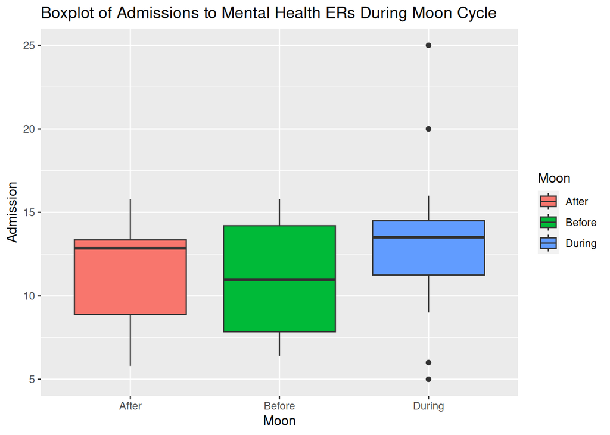

```r
# Visualizing the dataset and two variables as a box plot
ggplot(MentalHealth, aes(x = Moon, y = Admission, fill = Moon)) +
  geom_boxplot() +
  labs(title = "Boxplot of Admissions to Mental Health ERs During Moon Cycle")
```

```r
# Filtering out After and Before separately to compare to During
# After:
mentalhealth_after_during <- MentalHealth %>%
  filter(Moon != "Before")
# Before:
mentalhealth_before_during <- MentalHealth %>%
  filter(Moon != "After")
```

```r
# Calculation of observed difference in means
# After:
obs_diff_after_during <- mentalhealth_after_during %>%
  specify(Admission ~ Moon) %>%
  calculate(stat = "diff in means", order = c("After", "During"))
```

```
## Dropping unused factor levels Before from the supplied explanatory variable 'Moon'.
```

```r
# Before:
obs_diff_before_during <- mentalhealth_before_during %>%
  specify(Admission ~ Moon) %>%
  calculate(stat = "diff in means", order = c("Before", "During"))
```

```
## Dropping unused factor levels After from the supplied explanatory variable 'Moon'.
```

```r
# View calculated values
obs_diff_after_during
```

```
## Response: Admission (numeric)
## Explanatory: Moon (factor)
## # A tibble: 1 × 1
##    stat
##   <dbl>
## 1 -1.96
```

```r
obs_diff_before_during
```

```
## Response: Admission (numeric)
## Explanatory: Moon (factor)
## # A tibble: 1 × 1
##    stat
##   <dbl>
## 1  -2.5
```

Given the smaller size, after-during is better suited for hypothesis testing

```r
# Generate null distribution of delta
adm_in_null <- mentalhealth_after_during %>%
  specify(Admission ~ Moon) %>%
  hypothesize(null = "independence") %>%
  generate(reps = 5000, type = 'permute')
```

```
## Dropping unused factor levels Before from the supplied explanatory variable 'Moon'.
```

```r
# Calculate difference in means
adm_diff_in_null <- adm_in_null %>%
  calculate(stat = "diff in means", order = c("After", "During"))
# Slice a window of 5 replicates
adm_diff_in_null %>%
  slice(1:5)
```

```
## Response: Admission (numeric)
## Explanatory: Moon (factor)
## Null Hypothesis: independence
## # A tibble: 5 × 2
##   replicate     stat
##       <int>    <dbl>
## 1         1  0.0917
## 2         2 -0.808
## 3         3  0.442
## 4         4  0.00833
## 5         5 -0.192
```

```r
# Get the p-value for the calculated difference
adm_diff_in_null %>%
  get_pvalue(obs_stat = obs_diff_after_during, direction = "both")
```

```
## # A tibble: 1 × 1
##   p_value
##     <dbl>
## 1   0.326
```

```r
# Run a t test for comparison
t.test(Admission ~ Moon, var.equal = TRUE, data = mentalhealth_after_during)
```

```
##
##  Two Sample t-test
##
## data:  Admission by Moon
## t = -1.0735, df = 22, p-value = 0.2947
## alternative hypothesis: true difference in means between group After and group During is not equal to 0
## 95 percent confidence interval:
##  -5.741530  1.824863
## sample estimates:
##  mean in group After mean in group During
##             11.45833             13.41667
```

```r
# Fit data to regression model
mentalhealth_regression <- lm(formula = Admission ~ Moon, data = MentalHealth)
# Get regression table
# get_regression_table(mentalhealth_regression)
```